# Data check and tidy for IV mouse data

Jim Hughes

Wednesday, 5 July 2017

Data originally published: *Rozewski DM, Herman SEM, Towns WH, Mahoney E, Stefanovski MR, Shin JD, et al.* *Pharmacokinetics and Tissue Disposition of Lenalidomide in Mice. AAPS J.* *2012;14(4):872-82.*

# ——————————————————————————–

### Explore Data for Cleaning and Data Extraction

#### View column names and structure

```r
names(rawiv)
```

```
 [1] "Sample.ID"           "Dose..mg.kg."        "Mouse.Wt..g."        "Time..min."
 [5] "Avg.time..min."      "Plasma.DV..ng.mL."   "Plasma.Avg..ng.mL."  "Brain..ng.mL."
 [9] "Brain.Avg..ng.mL."   "Liver..ng.mL."       "Liver.Avg..ng.mL."   "Mscl..ng.mL."
[13] "Mscl.Avg..ng.mL."    "Hrt..ng.mL."         "Heart.Avg..ng.mL."   "Spln..ng.mL."
[17] "Spln.Avg..ng.mL."    "Lung..ng.mL."        ".Lung.Avg..ng.mL."   "Kidney..ng.mL."
[21] ".Kidney.Avg..ng.mL."
```

```r
str(rawiv)
```

```
'data.frame':   172 obs. of  21 variables:
 $ Sample.ID          : chr  "5hr_1" "5hr_2" "5hr_3" "5hr_4" ...
 $ Dose..mg.kg.       : num  0.5 0.5 0.5 0.5 0.5 0.5 0.5 0.5 0.5 0.5 ...
 $ Mouse.Wt..g.       : num  32 34 32 30 30 37 30 27 29 29 ...
 $ Time..min.         : num  300 300 300 300 302 ...
 $ Avg.time..min.     : num  NA NA NA NA 300 ...
 $ Plasma.DV..ng.mL.  : num  1.998 1.618 1.055 0.821 0.927 ...
 $ Plasma.Avg..ng.mL. : num  NA NA NA NA 1.28 ...
 $ Brain..ng.mL.      : num  NA NA NA NA NA NA NA NA NA NA ...
 $ Brain.Avg..ng.mL.  : num  NA NA NA NA NA NA NA NA NA NA ...
 $ Liver..ng.mL.      : num  12.7 13.6 NA 12.3 10.2 ...
 $ Liver.Avg..ng.mL.  : num  NA NA NA NA 12.2 ...
 $ Mscl..ng.mL.       : num  NA NA NA NA NA ...
 $ Mscl.Avg..ng.mL.   : num  NA NA NA NA NA ...
 $ Hrt..ng.mL.        : num  0.0589 0.3521 0.0889 0.657 1.2508 ...
 $ Heart.Avg..ng.mL.  : num  NA NA NA NA 0.482 ...
 $ Spln..ng.mL.       : num  NA NA NA NA NA ...
 $ Spln.Avg..ng.mL.   : num  NA NA NA NA NA ...
 $ Lung..ng.mL.       : num  3.57 3.43 1.59 NA 1.79 ...
 $ .Lung.Avg..ng.mL.  : num  NA NA NA NA 2.6 ...
 $ Kidney..ng.mL.     : num  1.91 2.6 2.41 4.12 2.69 ...
 $ .Kidney.Avg..ng.mL.: num  NA NA NA NA 2.75 ...
```

#### Check distribution of doses and weights

```r
  with(rawiv, table(Dose..mg.kg., useNA = "always"))
```

```
Dose..mg.kg.
 0.5  1.5    5   10 <NA>
  40   40   45   45    2
```

```r
  with(rawiv, table(Mouse.Wt..g., useNA = "always"))
```

```
Mouse.Wt..g.
  23   24   25   26   27   28   29   30   31   32   33   34   35   36   37   40 <NA>
   1    4   10   25   27   20   22   17   11   13   10    6    1    1    1    1    2
```

#### Check NA’s for non-binned data

```r
any(is.na(rawiv$Sample.ID))
```

```
[1] FALSE
```

```r
any(is.na(rawiv$Time..min.))
```

```
[1] TRUE
```

There are NA’s in the time column, this could be problematic. Identify where the NA’s are located

```r
rawiv[which(is.na(rawiv$Dose..mg.kg.)), ]
```

|  | Sample.ID | Dose..mg.kg. | Mouse.Wt..g. | Time..min. | Avg.time..min. | Plasma.DV..ng.mL. | Plasma.Avg..ng.mL. | Brain..ng.mL. | Brain.Avg..ng.mL. | Liver..ng.mL. | Liver.Avg..ng.mL. | Mscl..ng.mL. | Mscl.Avg..ng.mL. | Hrt..ng.mL. | Heart.Avg..ng.mL. | Spln..ng.mL. | Spln.Avg..ng.mL. | Lung..ng.mL. | .Lung.Avg..ng.mL. | Kidney..ng.mL. | .Kidney.Avg..ng.mL. |
| --- | --- | --- | --- | --- | --- | --- | --- | --- | --- | --- | --- | --- | --- | --- | --- | --- | --- | --- | --- | --- | --- |
| 114 | 5mg_20min_3_Repeat | NA | 26 | 20.26667 | NA | 520.1359 | NA | 16.417659 | NA | NA | NA | 22.47627 | NA | 19.709590 | NA | 92.22885 | NA | NA | NA | NA | NA |
| 116 | 5mg_20min_4_Repeat | NA | 32 | 20.00000 | NA | 265.9950 | NA | 6.386743 | NA | NA | NA | 16.63507 | NA | 6.566178 | NA | 52.01294 | NA | NA | NA | NA | NA |

```r
rawiv[which(is.na(rawiv$Mouse.Wt..g.)), ]
```

|  | Sample.ID | Dose..mg.kg. | Mouse.Wt..g. | Time..min. | Avg.time..min. | Plasma.DV..ng.mL. | Plasma.Avg..ng.mL. | Brain..ng.mL. | Brain.Avg..ng.mL. | Liver..ng.mL. | Liver.Avg..ng.mL. | Mscl..ng.mL. | Mscl.Avg..ng.mL. | Hrt..ng.mL. | Heart.Avg..ng.mL. | Spln..ng.mL. | Spln.Avg..ng.mL. | Lung..ng.mL. | .Lung.Avg..ng.mL. | Kidney..ng.mL. | .Kidney.Avg..ng.mL. |
| --- | --- | --- | --- | --- | --- | --- | --- | --- | --- | --- | --- | --- | --- | --- | --- | --- | --- | --- | --- | --- | --- |
| 113 | 5mg_20min_3 | 5 | NA | NA | NA | 0 | NA | 26.83955 | NA | 508.2313 | NA | 277.9028 | NA | 69.33291 | NA | 472.9238 | NA | 518.1404 | NA | 165.5198 | NA |
| 115 | 5mg_20min_4 | 5 | NA | NA | NA | 0 | NA | 20.53601 | NA | 516.3720 | NA | 247.0017 | NA | 57.74517 | NA | 1395.0259 | NA | 564.8902 | NA | 137.4807 | NA |

```r
rawiv[which(is.na(rawiv$Time..min.)), ]
```

|  | Sample.ID | Dose..mg.kg. | Mouse.Wt..g. | Time..min. | Avg.time..min. | Plasma.DV..ng.mL. | Plasma.Avg..ng.mL. | Brain..ng.mL. | Brain.Avg..ng.mL. | Liver..ng.mL. | Liver.Avg..ng.mL. | Mscl..ng.mL. | Mscl.Avg..ng.mL. | Hrt..ng.mL. | Heart.Avg..ng.mL. | Spln..ng.mL. | Spln.Avg..ng.mL. | Lung..ng.mL. | .Lung.Avg..ng.mL. | Kidney..ng.mL. | .Kidney.Avg..ng.mL. |
| --- | --- | --- | --- | --- | --- | --- | --- | --- | --- | --- | --- | --- | --- | --- | --- | --- | --- | --- | --- | --- | --- |
| 113 | 5mg_20min_3 | 5 | NA | NA | NA | 0 | NA | 26.83955 | NA | 508.2313 | NA | 277.9028 | NA | 69.33291 | NA | 472.9238 | NA | 518.1404 | NA | 165.5198 | NA |
| 115 | 5mg_20min_4 | 5 | NA | NA | NA | 0 | NA | 20.53601 | NA | 516.3720 | NA | 247.0017 | NA | 57.74517 | NA | 1395.0259 | NA | 564.8902 | NA | 137.4807 | NA |

NA’s appear to be as a result of a repeat sample, it was ascertained from correspondence with Mitch that these are in fact for the same mouse. These data entries will need to be combined into a single data entry.

#### Count number of samples (including repeats mentioned above)

```r
length(unique(rawiv$Sample.ID))
```

```
[1] 172
```

### Clean & Extract Data

Data converted to following units:

- Dose - mg
- AMT - ng
- Weight - g
- Concentrations - ng/mL
- Time - min

Sample IDs cleaned up using function that splits the ID string into ID and nominal time after dose (TADNOM).

```r
head(dataiv)
```

|  | ID | DOSEMGKG | DOSEMG | AMT | WT | TIME | PLA | BRA | LVR | MSC | HRT | SPL | LUN | KID |
| --- | --- | --- | --- | --- | --- | --- | --- | --- | --- | --- | --- | --- | --- | --- |
| 1 | 5hr_1 | 0.5 | 0.0160 | 16000 | 32 | 300.4167 | 1.9983602 | NA | 12.68317 | NA | 0.05888854 | NA | 3.573693 | 1.908639 |
| 2 | 5hr_2 | 0.5 | 0.0170 | 17000 | 34 | 300.0333 | 1.6182150 | NA | 13.58005 | NA | 0.35214547 | NA | 3.432398 | 2.599818 |
| 3 | 5hr_3 | 0.5 | 0.0160 | 16000 | 32 | 300.1167 | 1.0548369 | NA | NA | NA | 0.08888464 | NA | 1.589218 | 2.411031 |
| 4 | 5hr_4 | 0.5 | 0.0150 | 15000 | 30 | 300.2500 | 0.8205546 | NA | 12.29147 | NA | 0.65696034 | NA | NA | 4.118507 |
| 5 | 5hr_5 | 0.5 | 0.0150 | 15000 | 30 | 301.6500 | 0.9270570 | NA | 10.19113 | NA | 1.25083029 | NA | 1.793713 | 2.691368 |
| 6 | 3hr_1 | 0.5 | 0.0185 | 18500 | 37 | 180.2833 | 1.2053169 | NA | 14.33001 | NA | 0.40108217 | NA | 3.704915 | 3.479674 |

```r
IDiv <- end.splitter(dataiv$ID)
dataiv <- cbind(IDiv, dataiv[,-1])
head(dataiv)
```

|  | UID | ID | TADNOM | DOSEMGKG | DOSEMG | AMT | WT | TIME | PLA | BRA | LVR | MSC | HRT | SPL | LUN | KID |
| --- | --- | --- | --- | --- | --- | --- | --- | --- | --- | --- | --- | --- | --- | --- | --- | --- |
| 1 | 1 | 1 | 300 | 0.5 | 0.0160 | 16000 | 32 | 300.4167 | 1.9983602 | NA | 12.68317 | NA | 0.05888854 | NA | 3.573693 | 1.908639 |
| 2 | 2 | 2 | 300 | 0.5 | 0.0170 | 17000 | 34 | 300.0333 | 1.6182150 | NA | 13.58005 | NA | 0.35214547 | NA | 3.432398 | 2.599818 |
| 3 | 3 | 3 | 300 | 0.5 | 0.0160 | 16000 | 32 | 300.1167 | 1.0548369 | NA | NA | NA | 0.08888464 | NA | 1.589218 | 2.411031 |
| 4 | 4 | 4 | 300 | 0.5 | 0.0150 | 15000 | 30 | 300.2500 | 0.8205546 | NA | 12.29147 | NA | 0.65696034 | NA | NA | 4.118507 |
| 5 | 5 | 5 | 300 | 0.5 | 0.0150 | 15000 | 30 | 301.6500 | 0.9270570 | NA | 10.19113 | NA | 1.25083029 | NA | 1.793713 | 2.691368 |
| 6 | 6 | 1 | 180 | 0.5 | 0.0185 | 18500 | 37 | 180.2833 | 1.2053169 | NA | 14.33001 | NA | 0.40108217 | NA | 3.704915 | 3.479674 |

#### Check the nominal time against dose.

```r
with(dataiv, table(DOSEMGKG, TADNOM))
```

```
        TADNOM
DOSEMGKG 2 10 20 25 45 60 90 180 300 480
     0.5 5  5  0  5  5  5  5   5   5   0
     1.5 5  5  5  0  5  5  5   5   5   0
     5   5  5  5  0  5  5  5   5   5   5
     10  5  5  5  0  5  5  5   5   5   5
```

```r
dataiv[which(dataiv$TADNOM == "25"), ]
```

|  | UID | ID | TADNOM | DOSEMGKG | DOSEMG | AMT | WT | TIME | PLA | BRA | LVR | MSC | HRT | SPL | LUN | KID |
| --- | --- | --- | --- | --- | --- | --- | --- | --- | --- | --- | --- | --- | --- | --- | --- | --- |
| 26 | 26 | 1 | 25 | 0.5 | 0.0135 | 13500 | 27 | 20.26667 | 128.42002 | NA | 21.19532 | 16.628196 | 4.475332 | 156.08720 | 56.60610 | 16.10083 |
| 27 | 27 | 2 | 25 | 0.5 | 0.0165 | 16500 | 33 | 13.85000 | 81.14405 | NA | 64.25385 | 19.275615 | 3.719230 | 219.77955 | 60.71759 | 29.95265 |
| 28 | 28 | 3 | 25 | 0.5 | 0.0125 | 12500 | 25 | 19.98333 | 45.57491 | NA | 53.44819 | 4.277737 | 3.883230 | 78.57109 | 39.81549 | 18.72322 |
| 29 | 29 | 4 | 25 | 0.5 | 0.0130 | 13000 | 26 | 20.20000 | 70.51116 | NA | 33.52254 | 12.738494 | 8.886178 | 128.88911 | 21.53955 | 36.83820 |
| 30 | 30 | 5 | 25 | 0.5 | 0.0135 | 13500 | 27 | 19.95000 | 115.09252 | NA | 69.39923 | 3.872754 | 7.001963 | 66.03372 | 45.19763 | 27.23341 |

There are one set of values stated to have TADNOM as 25, but values were measured at 20mins, one at 13 which is odd. The TADNOM is likely meant to be 20, and since this data will only be used for categorising the data the TADNOM was changed to 20 for these rows.

The string splitting function identify the repeated sample with a repeated UID. There are two lots of concentrations in these rows, so which one is correct?

```r
subiv <- dataiv[which(with(dataiv, TADNOM == "20" & DOSEMGKG == 5 & !is.na(dataiv$WT))), ]
IDori <- dataiv[which(is.na(dataiv$WT)), ]
IDrep <- arrange(dataiv[which(is.na(dataiv$DOSEMGKG)), ], UID)
tissue.mean <- function(x) {
  colwise(mean)(x[c("PLA", "BRA", "LVR", "MSC", "HRT", "SPL", "LUN", "KID")])
}
rbind(tissue.mean(subiv), tissue.mean(IDori), tissue.mean(IDrep))
```

|  | PLA | BRA | LVR | MSC | HRT | SPL | LUN | KID |
| --- | --- | --- | --- | --- | --- | --- | --- | --- |
| 1 | 2867.2387 | 30.73858 | 417.2374 | 231.88730 | 62.14320 | 842.8801 | 627.2608 | 245.6739 |
| 2 | 0.0000 | 23.68778 | 512.3017 | 262.45222 | 63.53904 | 933.9749 | 541.5153 | 151.5002 |
| 3 | 393.0654 | 11.40220 | NA | 19.55567 | 13.13788 | 72.1209 | NA | NA |

The first row represents the mean of all data within the same time and dose bracket, excluding the repeated samples. The second row represents the samples with DOSEMGKG values and the third row represents the samples with WT & TIME values.

It appears that the row with WT & TIME has no usable concentrations. These rows were combined using the dependent variables and dose from one and the weight and time from the second.

The data should now be cleaned up and usable

### Further Data Checking

#### Check subject numbers

Also whether repeat sample was successfully removed.

```r
with(dataiv, table(ID))
```

```
ID
 1  2  3  4  5
34 34 34 34 34
```

```r
with(dataiv, table(UID))
```

```
UID
  1   2   3   4   5   6   7   8   9  10  11  12  13  14  15  16  17  18  19  20  21  22  23  24
  1   1   1   1   1   1   1   1   1   1   1   1   1   1   1   1   1   1   1   1   1   1   1   1
 25  26  27  28  29  30  31  32  33  34  35  36  37  38  39  40  41  42  43  44  45  46  47  48
  1   1   1   1   1   1   1   1   1   1   1   1   1   1   1   1   1   1   1   1   1   1   1   1
 49  50  51  52  53  54  55  56  57  58  59  60  61  62  63  64  65  66  67  68  69  70  71  72
  1   1   1   1   1   1   1   1   1   1   1   1   1   1   1   1   1   1   1   1   1   1   1   1
 73  74  75  76  77  78  79  80  81  82  83  84  85  86  87  88  89  90  91  92  93  94  95  96
  1   1   1   1   1   1   1   1   1   1   1   1   1   1   1   1   1   1   1   1   1   1   1   1
 97  98  99 100 101 102 103 104 105 106 107 108 109 110 111 112 113 114 115 116 117 118 119 120
  1   1   1   1   1   1   1   1   1   1   1   1   1   1   1   1   1   1   1   1   1   1   1   1
121 122 123 124 125 126 127 128 129 130 131 132 133 134 135 136 137 138 139 140 141 142 143 144
  1   1   1   1   1   1   1   1   1   1   1   1   1   1   1   1   1   1   1   1   1   1   1   1
145 146 147 148 149 150 151 152 153 154 155 156 157 158 159 160 161 162 163 164 165 166 167 168
  1   1   1   1   1   1   1   1   1   1   1   1   1   1   1   1   1   1   1   1   1   1   1   1
169 170
  1   1
```

```r
any(with(dataiv, table(UID)) > 2)
```

```
[1] FALSE
```

#### Check PK dose data

```r
with(dataiv, table(DOSEMGKG, TADNOM))
```

```
        TADNOM
DOSEMGKG 2 10 20 45 60 90 180 300 480
     0.5 5  5  5  5  5  5   5   5   0
     1.5 5  5  5  5  5  5   5   5   0
     5   5  5  5  5  5  5   5   5   5
     10  5  5  5  5  5  5   5   5   5
```

#### Check the dose columns

```r
with(dataiv, table(DOSEMG*1000))
```

```
12.5   13 13.5   14 14.5   15 15.5   16 16.5   17 17.5   18 18.5   36 37.5   39 40.5   42 43.5
   1    2    7    2    6    4    4    4    4    3    1    1    1    1    3    9    2    1    6
  45 46.5   48 49.5   51   60  130  135  140  145  150  155  160  165  230  240  250  260  270
   7    1    3    4    2    1    7    8   12    6    1    6    4    1    1    3    6    7   10
 280  290  300  320  330  340
   5    4    5    2    1    1
```

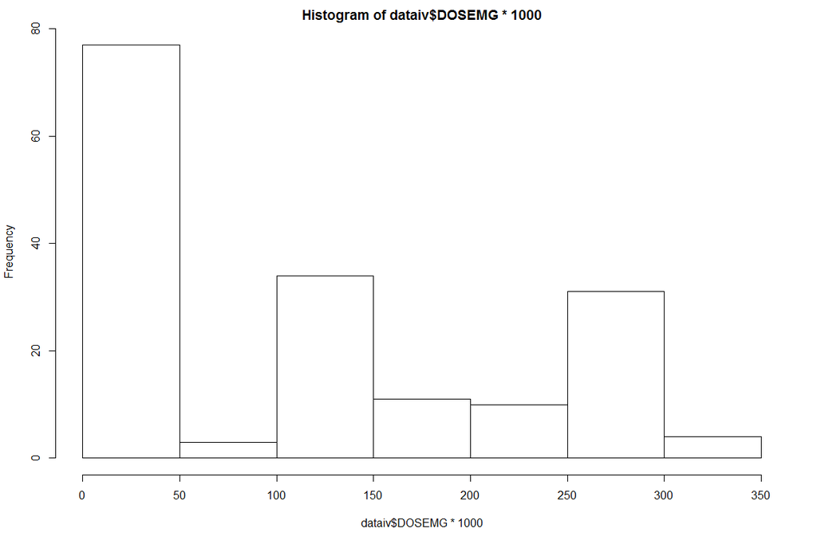

```r
hist(dataiv$DOSEMG*1000)
```

#### Check the distribution of DV

For all data and for the mean data

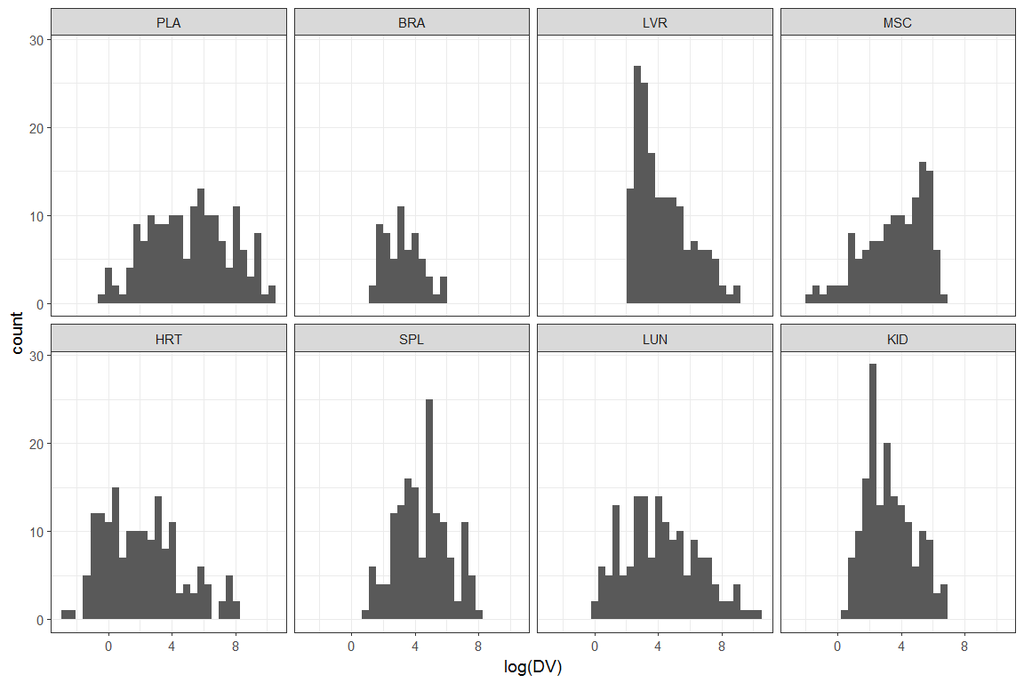

```r
meltiv <- melt(dataiv, id = c("UID", "ID", "TADNOM", "DOSEMGKG", "DOSEMG", "AMT", "WT", "TIME"))
colnames(meltiv) <- c(head(colnames(meltiv), 8), "TISSUE", "DV")
iv.distplot(meltiv, "alldata", NULL)
```

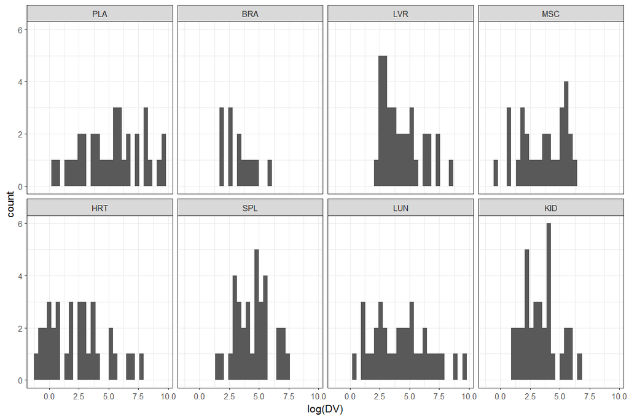

```r
meltiv.av <- melt(dataiv.av, id = c("DOSEMGKG","TADNOM", "DOSEMG", "AMT", "WT", "TIME"))
colnames(meltiv.av) <- c(head(colnames(meltiv.av), 6), "TISSUE", "DV")
iv.distplot(meltiv.av, "meandata", NULL)
```

#### Plot PK data

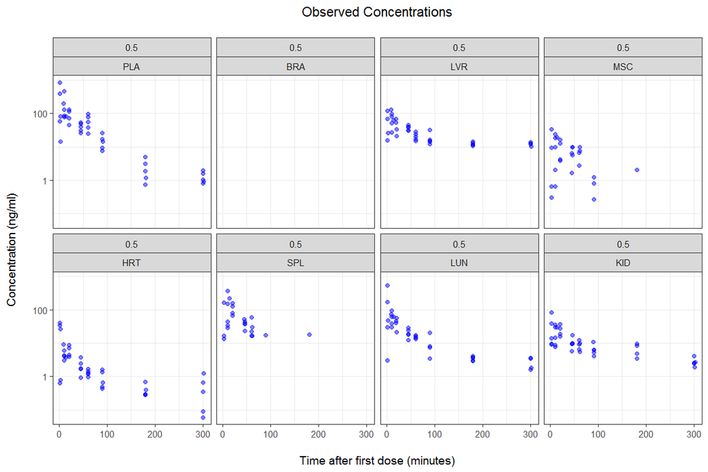

```r
plot.out <- NULL
iv.CvTplot(meltiv[meltiv$DOSEMGKG == 0.5,], "alldata", plot.out)
```

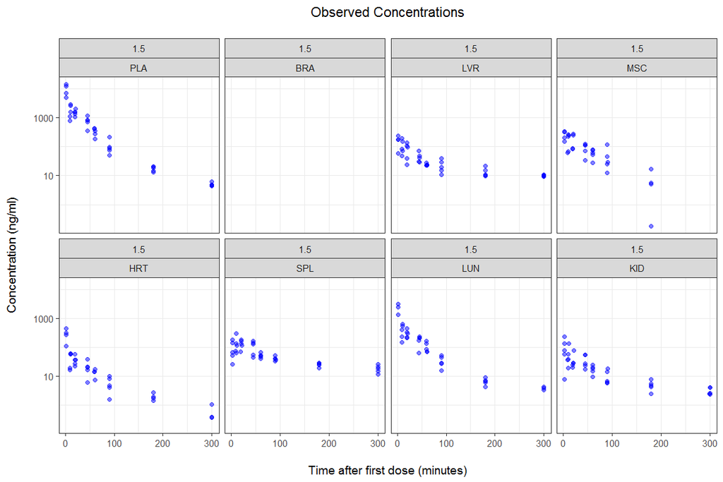

```r
iv.CvTplot(meltiv[meltiv$DOSEMGKG == 1.5,], "alldata", plot.out)
```

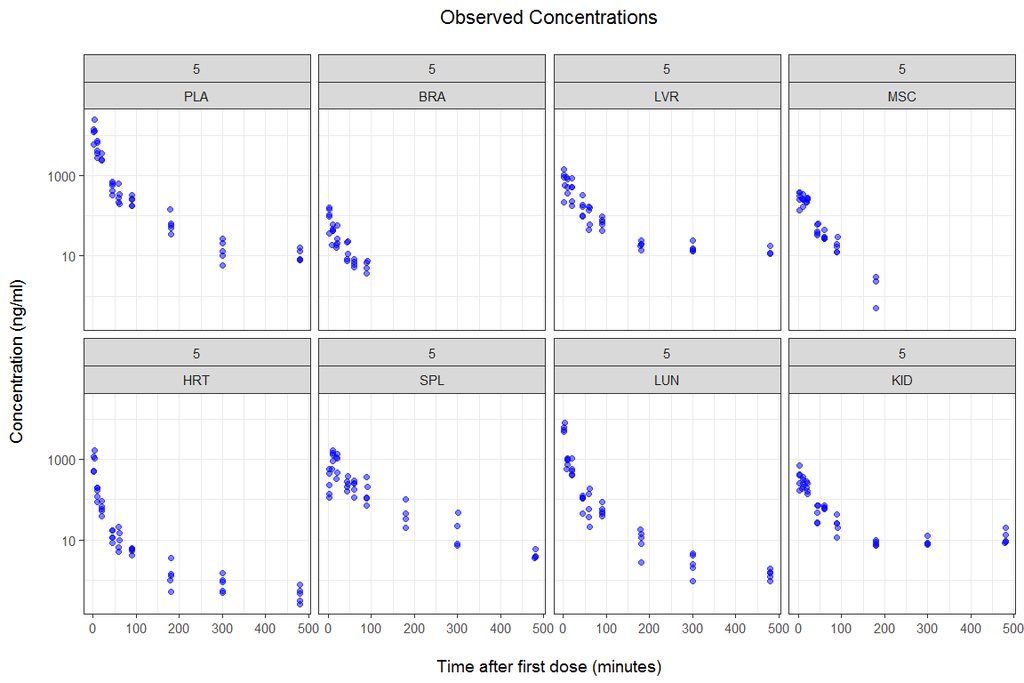

```r
iv.CvTplot(meltiv[meltiv$DOSEMGKG == 5,], "alldata", plot.out)
```

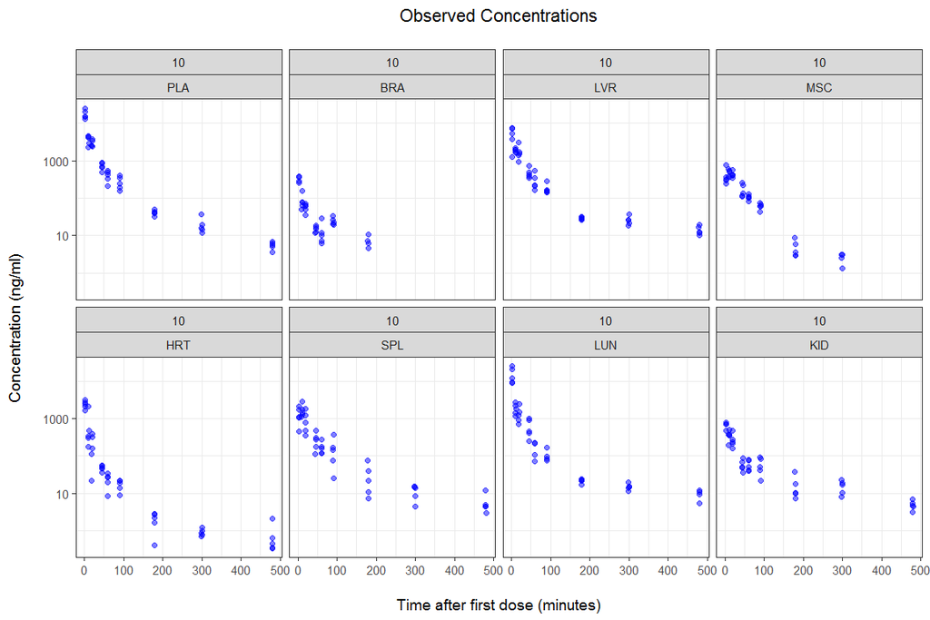

```r
iv.CvTplot(meltiv[meltiv$DOSEMGKG == 10,], "alldata", plot.out)
```

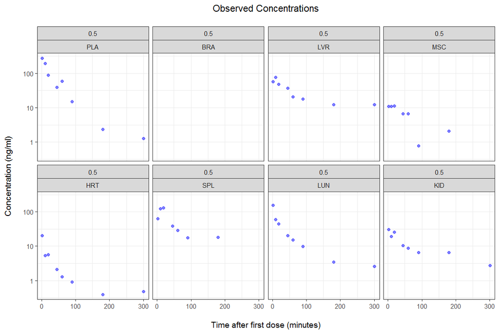

```r
iv.CvTplot(meltiv.av[meltiv.av$DOSEMGKG == 0.5,], "meandata", plot.out)
```

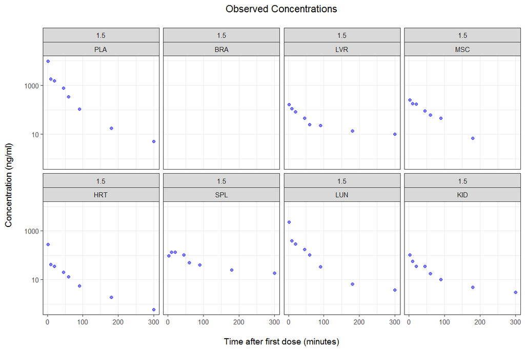

```r
iv.CvTplot(meltiv.av[meltiv.av$DOSEMGKG == 1.5,], "meandata", plot.out)
```

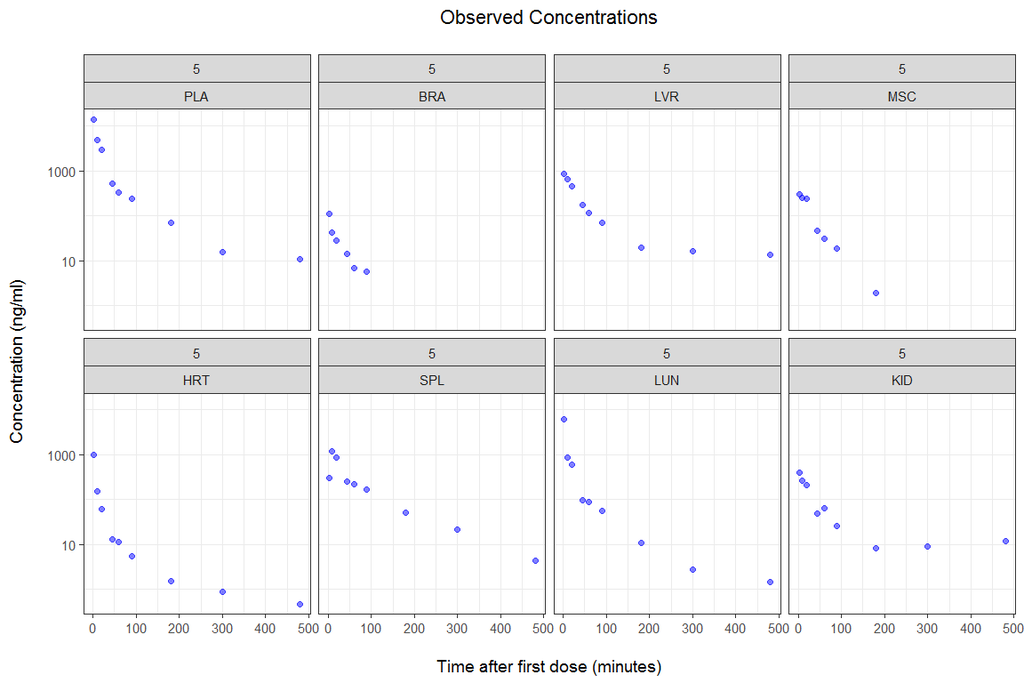

```r
iv.CvTplot(meltiv.av[meltiv.av$DOSEMGKG == 5,], "meandata", plot.out)
```

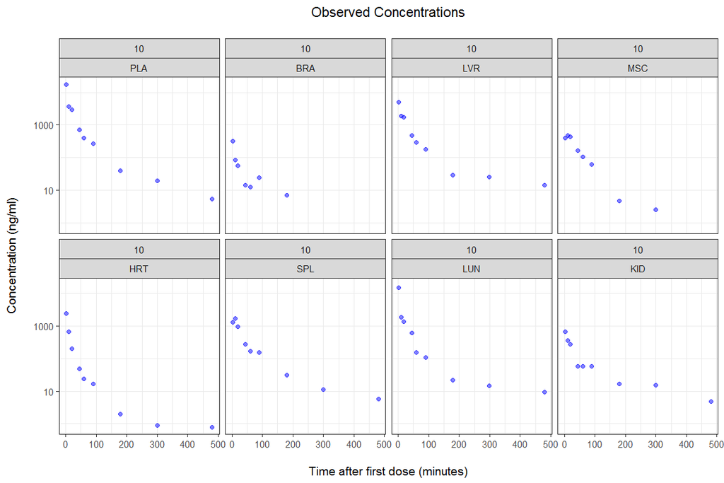

```r
iv.CvTplot(meltiv.av[meltiv.av$DOSEMGKG == 10,], "meandata", plot.out)
```

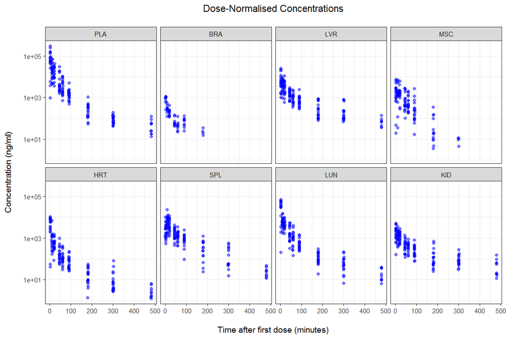

```r
iv.CvTplot(meltiv, "alldata", plot.out, dosenorm = T)
```

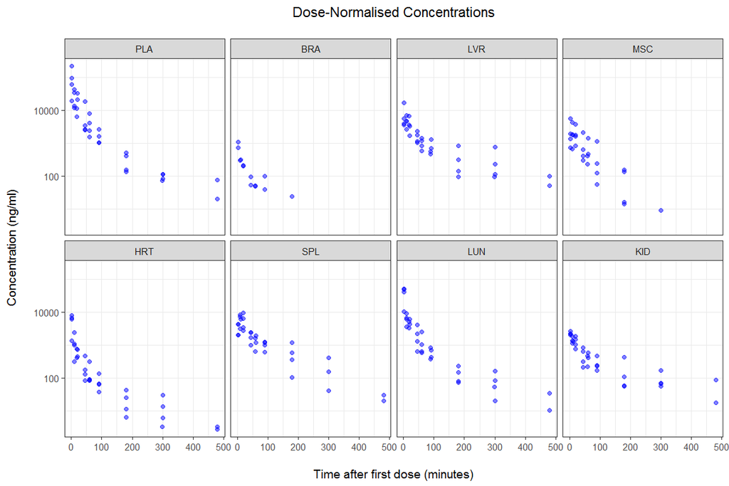

```r
iv.CvTplot(meltiv.av, "meandata", plot.out, dosenorm = T)
```

### Covariate Data Check

#### Count missing by dose group

```r
ddply(dataiv, .(DOSEMGKG), colwise(calculate.percent.missing))
```

| DOSEMGKG | UID | ID | TADNOM | DOSEMG | AMT | WT | TIME | PLA | BRA | LVR | MSC | HRT | SPL | LUN | KID |
| --- | --- | --- | --- | --- | --- | --- | --- | --- | --- | --- | --- | --- | --- | --- | --- |
| 0.5 | 0 | 0 | 0 | 0 | 0 | 0 | 0 | 0.000000 | 100.00000 | 5.000000 | 32.50000 | 0.0 | 37.500000 | 7.500000 | 2.500000 |
| 1.5 | 0 | 0 | 0 | 0 | 0 | 0 | 0 | 2.500000 | 100.00000 | 2.500000 | 20.00000 | 12.5 | 0.000000 | 10.000000 | 0.000000 |
| 5.0 | 0 | 0 | 0 | 0 | 0 | 0 | 0 | 4.444444 | 37.77778 | 6.666667 | 26.66667 | 0.0 | 6.666667 | 2.222222 | 4.444444 |
| 10.0 | 0 | 0 | 0 | 0 | 0 | 0 | 0 | 0.000000 | 26.66667 | 0.000000 | 13.33333 | 0.0 | 0.000000 | 6.666667 | 2.222222 |

#### Count missing by nominal time after dose

```r
ddply(dataiv, .(TADNOM), colwise(calculate.percent.missing))
```

| TADNOM | UID | ID | DOSEMGKG | DOSEMG | AMT | WT | TIME | PLA | BRA | LVR | MSC | HRT | SPL | LUN | KID |
| --- | --- | --- | --- | --- | --- | --- | --- | --- | --- | --- | --- | --- | --- | --- | --- |
| 2 | 0 | 0 | 0 | 0 | 0 | 0 | 0 | 5 | 55 | 10 | 10 | 5 | 10 | 15 | 5 |
| 10 | 0 | 0 | 0 | 0 | 0 | 0 | 0 | 0 | 50 | 5 | 0 | 0 | 0 | 0 | 0 |
| 20 | 0 | 0 | 0 | 0 | 0 | 0 | 0 | 10 | 50 | 0 | 5 | 0 | 0 | 0 | 0 |
| 45 | 0 | 0 | 0 | 0 | 0 | 0 | 0 | 0 | 50 | 0 | 0 | 0 | 0 | 0 | 0 |
| 60 | 0 | 0 | 0 | 0 | 0 | 0 | 0 | 0 | 55 | 0 | 5 | 5 | 0 | 10 | 5 |
| 90 | 0 | 0 | 0 | 0 | 0 | 0 | 0 | 0 | 55 | 0 | 10 | 0 | 20 | 10 | 0 |
| 180 | 0 | 0 | 0 | 0 | 0 | 0 | 0 | 0 | 80 | 0 | 35 | 5 | 25 | 0 | 5 |
| 300 | 0 | 0 | 0 | 0 | 0 | 0 | 0 | 0 | 100 | 5 | 80 | 10 | 30 | 15 | 5 |
| 480 | 0 | 0 | 0 | 0 | 0 | 0 | 0 | 0 | 100 | 20 | 100 | 0 | 10 | 10 | 0 |

#### Summary of missing data

```r
ddply(dataiv, .(DOSEMGKG, TADNOM), colwise(calculate.percent.missing))
```

| DOSEMGKG | TADNOM | UID | ID | DOSEMG | AMT | WT | TIME | PLA | BRA | LVR | MSC | HRT | SPL | LUN | KID |
| --- | --- | --- | --- | --- | --- | --- | --- | --- | --- | --- | --- | --- | --- | --- | --- |
| 0.5 | 2 | 0 | 0 | 0 | 0 | 0 | 0 | 0 | 100 | 20 | 20 | 0 | 40 | 0 | 0 |
| 0.5 | 10 | 0 | 0 | 0 | 0 | 0 | 0 | 0 | 100 | 0 | 0 | 0 | 0 | 0 | 0 |
| 0.5 | 20 | 0 | 0 | 0 | 0 | 0 | 0 | 0 | 100 | 0 | 0 | 0 | 0 | 0 | 0 |
| 0.5 | 45 | 0 | 0 | 0 | 0 | 0 | 0 | 0 | 100 | 0 | 0 | 0 | 0 | 0 | 0 |
| 0.5 | 60 | 0 | 0 | 0 | 0 | 0 | 0 | 0 | 100 | 0 | 20 | 0 | 0 | 20 | 0 |
| 0.5 | 90 | 0 | 0 | 0 | 0 | 0 | 0 | 0 | 100 | 0 | 40 | 0 | 80 | 20 | 0 |
| 0.5 | 180 | 0 | 0 | 0 | 0 | 0 | 0 | 0 | 100 | 0 | 80 | 0 | 80 | 0 | 20 |
| 0.5 | 300 | 0 | 0 | 0 | 0 | 0 | 0 | 0 | 100 | 20 | 100 | 0 | 100 | 20 | 0 |
| 1.5 | 2 | 0 | 0 | 0 | 0 | 0 | 0 | 20 | 100 | 20 | 20 | 20 | 0 | 40 | 0 |
| 1.5 | 10 | 0 | 0 | 0 | 0 | 0 | 0 | 0 | 100 | 0 | 0 | 0 | 0 | 0 | 0 |

[output cut: 24 more lines]

#### DV count

```r
DVsum(dataiv, group = "DOSEMGKG", uid =  "UID",
  col = c("AMT", "PLA", "BRA", "LVR", "MSC", "HRT", "SPL", "LUN", "KID")
)
```

| DOSEMGKG | SUBcount | AMTcount | AMTperSUB | PLAcount | PLAperSUB | BRAcount | BRAperSUB | LVRcount | LVRperSUB | MSCcount | MSCperSUB | HRTcount | HRTperSUB | SPLcount | SPLperSUB | LUNcount | LUNperSUB | KIDcount | KIDperSUB |
| --- | --- | --- | --- | --- | --- | --- | --- | --- | --- | --- | --- | --- | --- | --- | --- | --- | --- | --- | --- |
| 0.5 | 40 | 40 | 1 | 40 | 1.0000000 | 0 | 0.0000000 | 38 | 0.9500000 | 27 | 0.6750000 | 40 | 1.000 | 25 | 0.6250000 | 37 | 0.9250000 | 39 | 0.9750000 |
| 1.5 | 40 | 40 | 1 | 39 | 0.9750000 | 0 | 0.0000000 | 39 | 0.9750000 | 32 | 0.8000000 | 35 | 0.875 | 40 | 1.0000000 | 36 | 0.9000000 | 40 | 1.0000000 |
| 5.0 | 45 | 45 | 1 | 43 | 0.9555556 | 28 | 0.6222222 | 42 | 0.9333333 | 33 | 0.7333333 | 45 | 1.000 | 42 | 0.9333333 | 44 | 0.9777778 | 43 | 0.9555556 |
| 10.0 | 45 | 45 | 1 | 45 | 1.0000000 | 33 | 0.7333333 | 45 | 1.0000000 | 39 | 0.8666667 | 45 | 1.000 | 45 | 1.0000000 | 42 | 0.9333333 | 44 | 0.9777778 |

#### Plot by Factor

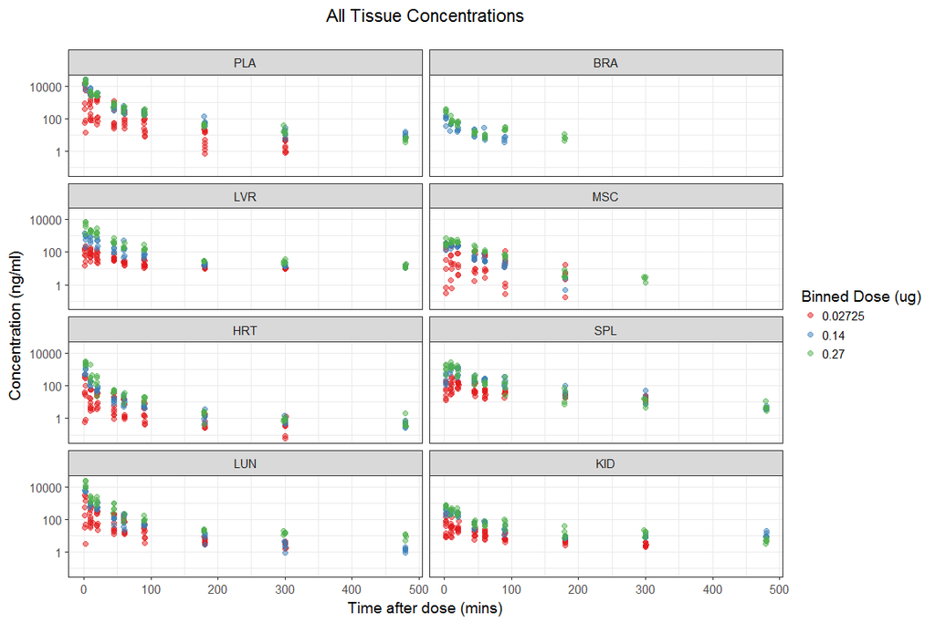

```r
plotByFactor("DOSE_bin", "Binned Dose (ug)", plotdata, plot.out)
```

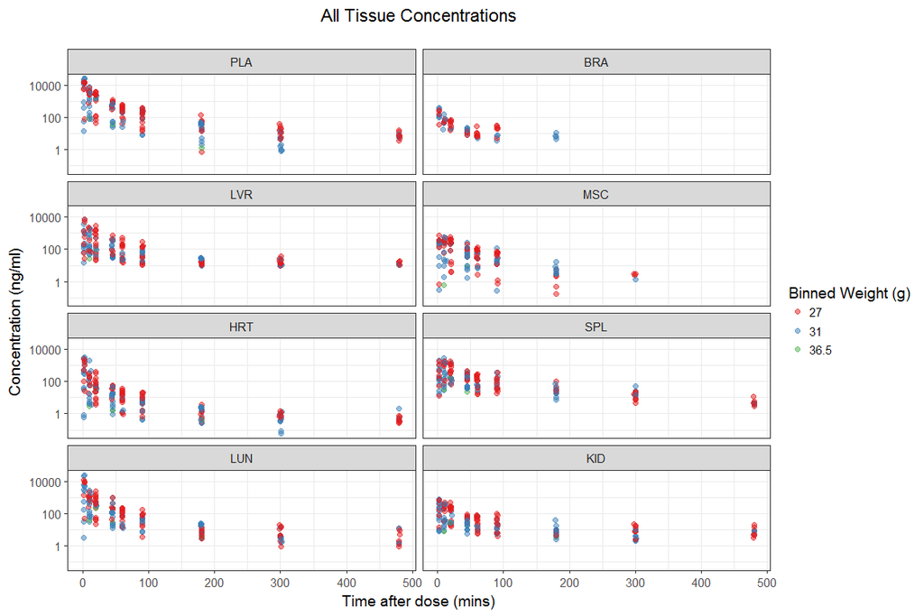

```r
plotByFactor("WT_bin", "Binned Weight (g)", plotdata, plot.out)
```